# p8105_hw3_qz2527

kindle zhang

2023-10-10

## Problem 1

import the data from database

```r
library(p8105.datasets)
data("instacart")
```

**The goal is to do some exploration of this dataset. To that end, write a short description of the dataset, noting the size and structure of the data, describing some key variables, and giving illstrative examples of observations. Then, do or answer the following (commenting on the results of each):**

this dataframe is a dataset which has 1384617 observations and 15 variables. This dataset is used to record some informations about Instacart which is an online grocery service. There’re some important variables in this dataset: order_id, product_id, add_to_cart_order, reordered, user_id, eval_set, order_number, order_dow, order_hour_of_day, days_since_prior_order, product_name, aisle_id, department_id, aisle, department. The explanation of each variable is as fallow: - order_id: order identifier

- product_id: product identifier
- add_to_cart_order: order in which each product was added to cart
- reordered: 1 if this prodcut has been ordered by this user in the past, 0 otherwise
- user_id: customer identifier
- eval_set: which evaluation set this order belongs in (Note that the data for use in this class is exclusively from the “train” eval_set)
- order_number: the order sequence number for this user (1=first, n=nth)
- order_dow: the day of the week on which the order was placed
- order_hour_of_day: the hour of the day on which the order was placed
- days_since_prior_order: days since the last order, capped at 30, NA if order_number=1
- product_name: name of the product
- aisle_id: aisle identifier
- department_id: department identifier
- aisle: the name of the aisle
- department: the name of the department

**How many aisles are there, and which aisles are the most items ordered from?**

```r
instacart |>
  group_by(aisle) |>
  summarize(n_obs = n()) |>
  arrange(desc(n_obs))
```

```
## # A tibble: 134 × 2
##    aisle                          n_obs
##    <chr>                          <int>
##  1 fresh vegetables              150609
##  2 fresh fruits                  150473
##  3 packaged vegetables fruits     78493
##  4 yogurt                         55240
##  5 packaged cheese                41699
##  6 water seltzer sparkling water  36617
##  7 milk                           32644
##  8 chips pretzels                 31269
##  9 soy lactosefree                26240
## 10 bread                          23635
## # ℹ 124 more rows
```

There are 134 aisles among which the `fresh vegetables` is the most popular.

**Make a plot that shows the number of items ordered in each aisle, limiting this to aisles with more than 10000 items ordered. Arrange aisles sensibly, and organize your plot so others can read it.**

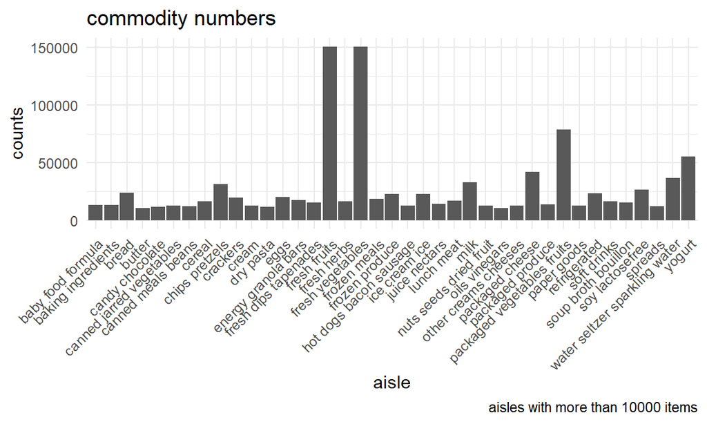

```r
instacart |>
  group_by(aisle) |>
  summarize(n_obs = n()) |>
  filter(n_obs > 10000) |>
  arrange(desc(n_obs)) |>
  ggplot(aes(x = aisle, y = n_obs)) + geom_col()+
  labs(
    title = "commodity numbers",
    x = "aisle",
    y = "counts",
    caption = "aisles with more than 10000 items"
  ) +
  theme(
    axis.text.x = element_text(
      angle = 45, vjust = 1, hjust = 1) )
```

**Make a table showing the three most popular items in each of the aisles “baking ingredients”, “dog food care”, and “packaged vegetables fruits”. Include the number of times each item is ordered in your table.**

```r
instacart |>
  filter(aisle == "baking ingredients" | aisle == "dog food care"| aisle == "packaged vegetables fruits") |>
  group_by(aisle, product_name) |>
  summarise(n_obs = n()) |>
  arrange(desc(n_obs)) |>
  filter(row_number() <= 3) |>
  knitr::kable(digits = 2)
```

| aisle | product_name | n_obs |
| --- | --- | --- |
| packaged vegetables fruits | Organic Baby Spinach | 9784 |
| packaged vegetables fruits | Organic Raspberries | 5546 |
| packaged vegetables fruits | Organic Blueberries | 4966 |
| baking ingredients | Light Brown Sugar | 499 |
| baking ingredients | Pure Baking Soda | 387 |
| baking ingredients | Cane Sugar | 336 |
| dog food care | Snack Sticks Chicken & Rice Recipe Dog Treats | 30 |
| dog food care | Organix Chicken & Brown Rice Recipe | 28 |
| dog food care | Small Dog Biscuits | 26 |

**Make a table showing the mean hour of the day at which Pink Lady Apples and Coffee Ice Cream are ordered on each day of the week; format this table for human readers (i.e. produce a 2 x 7 table).**

```r
instacart |>
  select(product_name, order_dow, order_hour_of_day) |>
  filter(product_name == "Pink Lady Apples" | product_name == "Coffee Ice Cream") |>
  group_by(product_name, order_dow) |>
  summarise(mean_hour = mean(order_hour_of_day)) |>
  mutate(
    order_dow = case_match(
      order_dow,
      0 ~ "Monday",
      1 ~ "Tuesday",
      2 ~ "Wednesday",
      3 ~ "Thursday",
      4 ~ "Friday",
      5 ~ "Saturday",
      6 ~ "Sunday"
    )
  ) |>
  rename(week_day = order_dow) |>
  pivot_wider(
    names_from = week_day,
    values_from = mean_hour
  ) |>
  knitr::kable(digits = 2)
```

| product_name | Monday | Tuesday | Wednesday | Thursday | Friday | Saturday | Sunday |
| --- | --- | --- | --- | --- | --- | --- | --- |
| Coffee Ice Cream | 13.77 | 14.32 | 15.38 | 15.32 | 15.22 | 12.26 | 13.83 |
| Pink Lady Apples | 13.44 | 11.36 | 11.70 | 14.25 | 11.55 | 12.78 | 11.94 |

## Problem 2

import the data

```r
library(p8105.datasets)
data("brfss_smart2010")
```

**First, do some data cleaning:**

- format the data to use appropriate variable names
- focus on the “Overall Health” topic
- include only responses from “Excellent” to “Poor”
- organize responses as a factor taking levels ordered from “Poor” to “Excellent”

```r
brfss_smart2010 =
  brfss_smart2010 |>
    janitor::clean_names() |>
    select(year, locationabbr, locationdesc, topic, response, sample_size, data_value, display_order, geo_location) |>
  filter(topic == "Overall Health") |>
  arrange(year, locationdesc, desc(display_order)) |>
  mutate(
    response = fct_reorder(response, display_order, .na_rm = FALSE)
  )
```

**Using this dataset, do or answer the following (commenting on the results of each):**

- In 2002, which states were observed at 7 or more locations? What about in 2010?

```r
brfss_smart2010 |>
  filter(year == 2002) |>
  group_by(locationabbr) |>
  summarise(n_obs = n()/5) |>
  filter(n_obs >= 7) |>
  arrange(desc(n_obs)) |>
  knitr::kable(digits = 2)
```

| locationabbr | n_obs |
| --- | --- |
| PA | 10 |
| MA | 8 |
| NJ | 8 |
| CT | 7 |
| FL | 7 |
| NC | 7 |

```r
brfss_smart2010 |>
  filter(year == 2010) |>
  group_by(locationabbr) |>
  summarise(n_obs = n()/5) |>
  filter(n_obs >= 7) |>
  arrange(desc(n_obs)) |>
  knitr::kable(digits = 2)
```

| locationabbr | n_obs |
| --- | --- |
| FL | 41 |
| NJ | 19 |
| TX | 16 |
| CA | 12 |
| MD | 12 |
| NC | 12 |
| NE | 10 |
| WA | 10 |
| MA | 9 |
| NY | 9 |
| OH | 8 |
| CO | 7 |
| PA | 7 |
| SC | 7 |

- Construct a dataset that is limited to `Excellent` responses, and contains, year, state, and a variable that averages the `data_value` across locations within a state. Make a “spaghetti” plot of this average value over time within a state (that is, make a plot showing a line for each state across years – the `geom_line` geometry and `group` aesthetic will help).

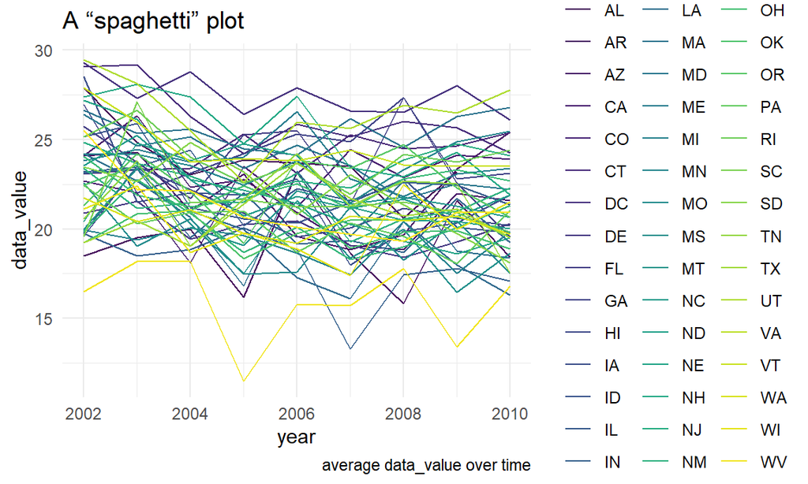

```r
brfss_smart2010 |>
  filter(response == "Excellent") |>
  select(year, locationabbr, data_value) |>
  group_by(year, locationabbr) |>
  summarise(
    mean_value = mean(data_value, na.rm = TRUE)
  ) |>
  group_by(locationabbr, year, mean_value) |>
  summarise() |>
  ggplot(aes(x = year, y = mean_value, color = locationabbr)) + geom_line() + labs(
    title = "A “spaghetti” plot",
    x = "year",
    y = "data_value",
    color = "State",
    caption = "average data_value over time"
  )+
  theme(legend.position = "right")
```

- Make a two-panel plot showing, for the years 2006, and 2010, distribution of `data_value` for responses (“Poor” to “Excellent”) among locations in NY State.

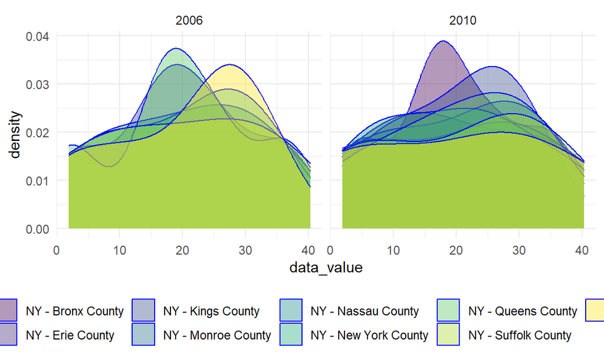

```r
brfss_smart2010 |>
  filter(year == 2006 | year == 2010) |>
  filter(locationabbr == "NY") |>
  select(year, locationdesc, response, data_value) |>
  ggplot(aes(x = data_value, fill = locationdesc)) +            geom_density(alpha = .4, color = "blue") +
  facet_grid(. ~ year)
```

## Problem 3

import the data

```r
data_dp =
  read_csv("./data_file/nhanes_covar.csv", skip = 4) |>
  janitor::clean_names()
data_mims =
  read_csv("./data_file/nhanes_accel.csv") |>                janitor::clean_names()
```

**Load, tidy, merge, and otherwise organize the data sets. Your final dataset should include all originally observed variables; exclude participants less than 21 years of age, and those with missing demographic data; and encode data with reasonable variable classes (i.e. not numeric, and using factors with the ordering of tables and plots in mind).**

```r
data_final =
  left_join(data_dp, data_mims, by = "seqn") |>
  filter(age >= 21) |>
  drop_na(sex, age, bmi, education) |>
  mutate(
    sex = case_match(
      sex,
      1 ~ "male",
      2 ~ "female"),
    education = case_match(
      education,
      1 ~ "low",
      2 ~ "medium",
      3 ~ "high"
    )
  )|>
  mutate(
    sex = fct_relevel(
      sex,
      c("male", "female")
    ),
    education = fct_relevel(
      education,
      c("low", "medium", "high"))
  )
```

**Produce a reader-friendly table for the number of men and women in each education category, and create a visualization of the age distributions for men and women in each education category. Comment on these items.**

```r
data_final |>
  group_by(sex, education) |>
  summarize(n_obs = n()) |>
  pivot_wider(
    names_from = sex,
    values_from = n_obs
  ) |>
  knitr::kable(digits = 2)
```

[output not shown]

| education | male | female |
| --- | --- | --- |
| low | 27 | 28 |
| medium | 35 | 23 |
| high | 56 | 59 |

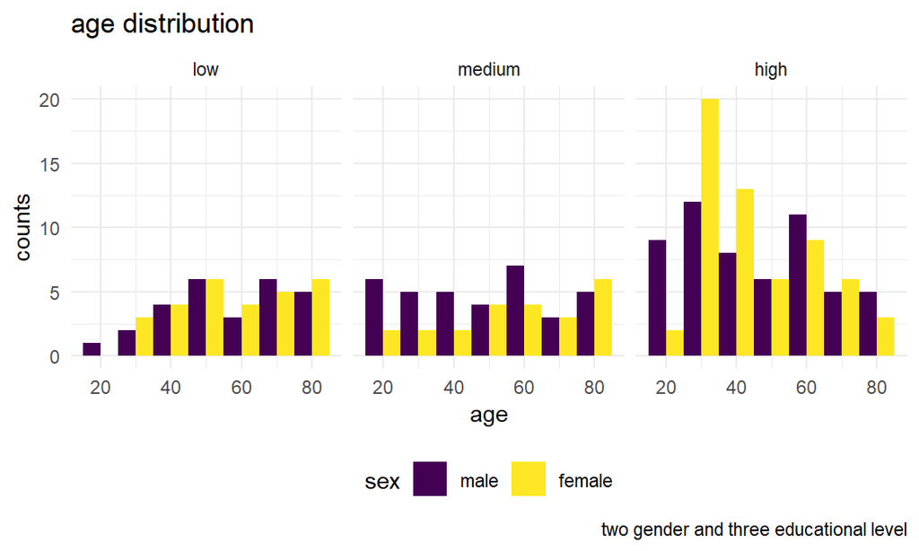

```r
data_final |>
  ggplot(aes(x = age, fill = sex)) +
  geom_histogram(position = "dodge", binwidth = 10) +
  facet_grid(. ~ education) +
  labs(
    title = "age distribution",
    x = "age",
    y = "counts",
    caption = "two gender and three educational level"
  )
```

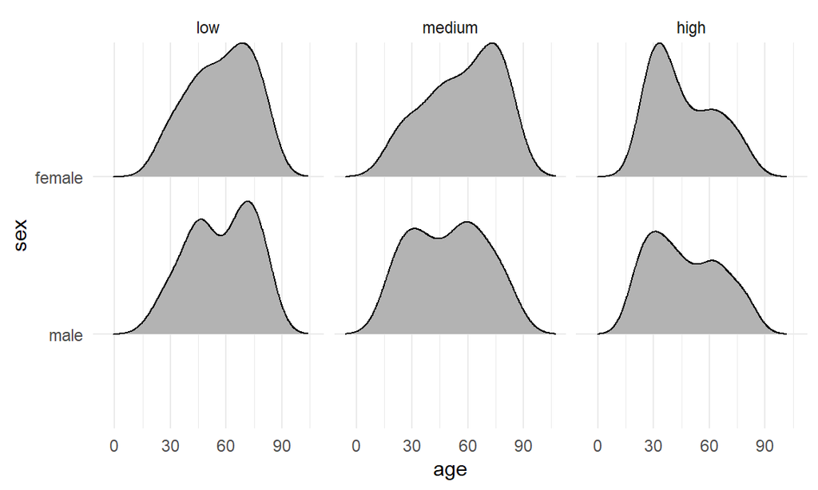

```r
data_final |>
  ggplot(aes(x = age, y = sex)) +
  geom_density_ridges(scale = .85) +
  facet_grid(. ~ education)
```

according to the table and picture we got above, we can find. In the education level 1 and 3, the number of female and male nearly equal to each other. However, in the level 2, male’s number is larger. What’s more, younger people is more likely to have a higher education level.

**Traditional analyses of accelerometer data focus on the total activity over the day. Using your tidied dataset, aggregate across minutes to create a total activity variable for each participant. Plot these total activities (y-axis) against age (x-axis); your plot should compare men to women and have separate panels for each education level. Include a trend line or a smooth to illustrate differences. Comment on your plot.**

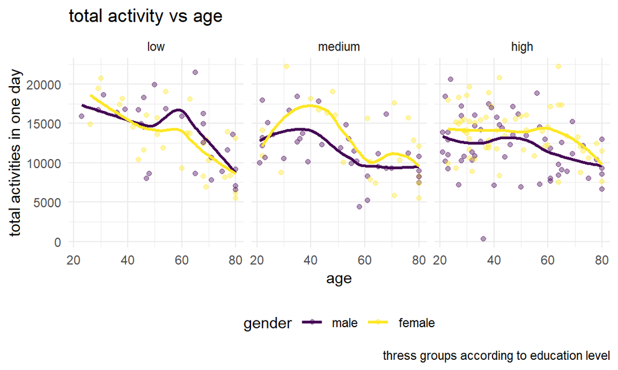

```r
data_final_total =
  data_final |>
    pivot_longer(
      min1:min1440,
      names_to = "time",
      values_to = "act"
    ) |>
    group_by(seqn) |>
    summarise(
      total_act = round(sum(act, na.rm = TRUE), digit = 0)
    )

data_final_new =
  left_join(data_final, data_final_total, by = "seqn") |>
  select(seqn, sex, age, bmi,education, total_act)

data_final_new |>
  ggplot(aes(x = age, y = total_act, color = sex)) +
  geom_point(alpha = .4) +
  geom_smooth(se = FALSE) +
  facet_grid(. ~ education) +
  labs(
    title = "total activity vs age",
    x = "age",
    y = "total activities in one day",
    color = "gender",
    caption = "thress groups according to education level"
  )
```

according to the picture, we can conclude two conclusions: 1, In general, if a person’s age is larger, the total activity in one day will be smaller. 2, In medium and high education level, the female has a overall higher total activities level than the male participants.

**Accelerometer data allows the inspection activity over the course of the day. Make a three-panel plot that shows the 24-hour activity time courses for each education level and use color to indicate sex. Describe in words any patterns or conclusions you can make based on this graph; including smooth trends may help identify differences.**

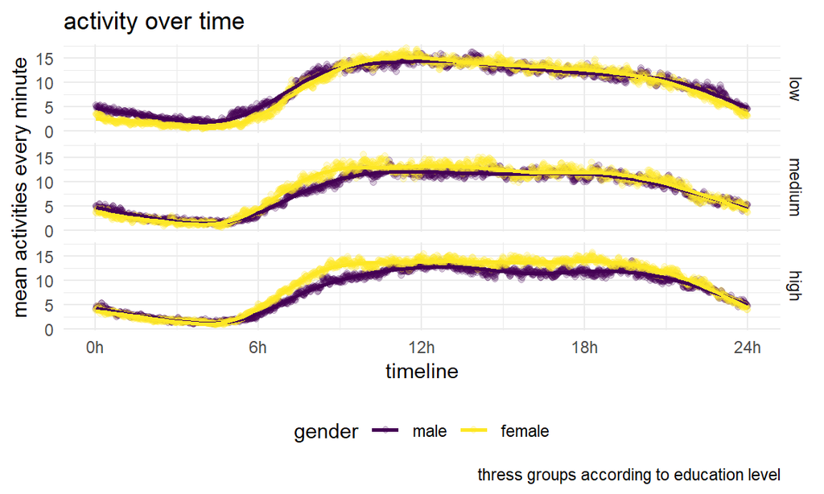

```r
data_final |>
  pivot_longer(
      min1:min1440,
      names_to = "time",
      values_to = "act"
    ) |>
  separate(time, into = c("time_1", "time_2"), sep = 3) |>
  mutate(time_2 = as.numeric(time_2)) |>
  group_by(sex, education, time_2) |>
  summarise(
    n_obs= n(),
    mean_act = mean(act, na.rm = TRUE)
  ) |>
  select(education,everything()) |>
  ggplot(aes(x = time_2, y = mean_act, color = sex)) +
  geom_point(alpha = .2) +
  geom_smooth(se = FALSE) +
  facet_grid(education ~ .) +
  labs(
    title = "activity over time",
    x = "timeline",
    y = "mean activities every minute",
    color = "gender",
    caption = "thress groups according to education level"
  ) +
  scale_x_continuous(
    breaks = c( 0, 360, 720, 1080, 1440),
    labels = c("0h", "6h", "12h", "18h", "24h")
    )
```